# 03 · Compare Before & After Cleaning

This notebook visualizes how the production cleaner transforms the dataset, highlighting wins in data quality and any trade-offs introduced by stricter rules.

## Notebook goals

- Quantify improvements in missing data, duplicates, and quality metrics
- Visualize numeric distributions before vs. after cleaning
- Demonstrate the geographic impact of coordinate validation
- Provide an audit trail using `CleaningReport` artifacts

```python
from __future__ import annotations

from pathlib import Path
import importlib.util
import sys

import dask.dataframe as dd
import matplotlib.pyplot as plt
from IPython.display import display
import pandas as pd
import seaborn as sns

plt.style.use("seaborn-v0_8")
sns.set_theme(style="ticks")
pd.set_option("display.max_columns", 40)

PROJECT_ROOT = Path.cwd().resolve().parents[1]
DATA_PATH = PROJECT_ROOT / "data" / "national_water_plan.csv"
SCRIPTS_DIR = PROJECT_ROOT / "scripts"


def load_module(module_name: str, file_path: Path):
    if module_name in sys.modules:
        return sys.modules[module_name]
    spec = importlib.util.spec_from_file_location(module_name, file_path)
    module = importlib.util.module_from_spec(spec)
    sys.modules[module_name] = module
    spec.loader.exec_module(module)
    return module


data_loader = load_module("project_data_loader", SCRIPTS_DIR / "data-loader.py")
DataLoader = data_loader.DataLoader
DataConfig = data_loader.DataConfig


data_cleaner = load_module("project_data_cleaner", SCRIPTS_DIR / "data-cleaner.py")
DataCleanerConfig = data_cleaner.DataCleanerConfig
WaterDataCleaner = data_cleaner.WaterDataCleaner
CleaningReport = data_cleaner.CleaningReport
```

```
Pydantic enhancements module not available. Using basic features only.
```

[output not shown]

[output not shown]

## 1. Load raw data & create paired samples

We reuse the DataLoader to keep validation consistent, then grab a manageable slice for plotting.

```python
data_config = DataConfig(filepath=str(DATA_PATH))
loader = DataLoader(data_config)
raw_ddf, exploration_report = loader.load_and_explore_data()

SAMPLE_ROWS = 15_000
raw_sample_pdf = raw_ddf.head(SAMPLE_ROWS, compute=True)
print(f"Sample rows: {len(raw_sample_pdf):,} / {exploration_report.metadata.rows:,}")
```

[output not shown]

[output not shown]

[output not shown]

```
Duplicate check skipped (not supported for this operation)
```

```
High missing data percentage: 8.10%
```

```
Sample rows: 14,187 / 14,187
```

## 2. Run the cleaner with a representative config

Mirror the production defaults (strict mode, duplicates removal, coordinate checks) but skip filesystem writes for notebook speed.

```python
comparison_config = DataCleanerConfig(
    strict_mode=True,
    remove_duplicates=True,
    remove_outliers=True,
    outlier_std_threshold=3.0,
    min_valid_spill_years=3,
    fill_missing_values=False,
    create_backup=False,
    save_cleaning_report=False,
)

cleaner = WaterDataCleaner(comparison_config)
cleaned_ddf, cleaning_report = cleaner.clean_data(raw_sample_pdf.copy(), output_dir=None)
clean_sample_pdf = cleaned_ddf.compute()
print(f"Rows before: {len(raw_sample_pdf):,}")
print(f"Rows after:  {len(clean_sample_pdf):,}")
```

```
2025-11-21 11:42:26,953 - project_data_cleaner - INFO - Starting data cleaning pipeline
```

```
2025-11-21 11:42:26,955 - project_data_cleaner - INFO - Converting Pandas DataFrame to Dask DataFrame
```

```
2025-11-21 11:42:26,971 - project_data_cleaner - INFO - Collecting initial statistics
```

```
2025-11-21 11:42:27,037 - project_data_cleaner - WARNING - Could not calculate initial duplicates
```

```
2025-11-21 11:42:27,039 - project_data_cleaner - INFO - Step 1: Validating columns
```

```
2025-11-21 11:42:27,040 - project_data_cleaner - INFO - Missing optional columns: ['Site Name', 'Permit Number']
```

```
2025-11-21 11:42:27,041 - project_data_cleaner - INFO - Step 2: Cleaning coordinates
```

```
2025-11-21 11:42:27,102 - project_data_cleaner - INFO - Step 3: Cleaning spill events
```

```
2025-11-21 11:42:27,103 - project_data_cleaner - INFO - Cleaning 3 spill event columns
```

```
2025-11-21 11:42:27,222 - project_data_cleaner - WARNING - Removing 233 outliers from Spill Events 2020
```

```
2025-11-21 11:42:27,377 - project_data_cleaner - WARNING - Removing 219 outliers from Spill Events 2021
```

```
2025-11-21 11:42:27,577 - project_data_cleaner - WARNING - Removing 238 outliers from Spill Events 2022
```

```
2025-11-21 11:42:27,746 - project_data_cleaner - WARNING - Removing 3253 rows with < 3 valid spill years
```

```
2025-11-21 11:42:27,748 - project_data_cleaner - INFO - Step 4: Cleaning text fields
```

```
2025-11-21 11:42:28,225 - project_data_cleaner - INFO - Step 5: Removing duplicates
```

```
2025-11-21 11:42:29,120 - project_data_cleaner - INFO - Step 6: Handling missing values
```

```
2025-11-21 11:42:29,672 - project_data_cleaner - WARNING - Removing 1990 rows exceeding missing value threshold
```

```
2025-11-21 11:42:29,674 - project_data_cleaner - INFO - Collecting final statistics
```

```
2025-11-21 11:42:31,549 - project_data_cleaner - INFO - Cleaning completed: 14187 -> 8944 rows (63.0% retained) in 4.60s
```

```
Rows before: 14,187
Rows after:  8,944
```

## 3. Summary metrics

Capture missing %, duplicates, and memory footprint for the paired dataframes.

```python
def summarize_frame(df: pd.DataFrame) -> dict:
    total_cells = df.shape[0] * df.shape[1]
    missing_pct = (df.isna().sum().sum() / total_cells * 100) if total_cells else 0
    duplicate_rows = df.duplicated().sum()
    memory_mb = df.memory_usage(deep=True).sum() / 1e6
    return {
        "rows": df.shape[0],
        "columns": df.shape[1],
        "missing_pct": missing_pct,
        "duplicate_rows": duplicate_rows,
        "memory_mb": memory_mb,
    }

comparison_summary = pd.DataFrame(
    {
        "raw": summarize_frame(raw_sample_pdf),
        "cleaned": summarize_frame(clean_sample_pdf),
    }
).transpose()
comparison_summary
```

|  | rows | columns | missing_pct | duplicate_rows | memory_mb |
| --- | --- | --- | --- | --- | --- |
| raw | 14187.0 | 38.0 | 8.096367 | 0.0 | 5.871614 |
| cleaned | 8944.0 | 38.0 | 5.173418 | 0.0 | 3.855667 |

```python
report_metrics = pd.Series(cleaning_report.quality_metrics)
display(report_metrics.to_frame("value"))
```

|  | value |
| --- | --- |
| rows_removed | 5243.000000 |
| rows_retained_percent | 63.043631 |
| initial_missing_percent | 8.096367 |
| final_missing_percent | 5.173418 |
| duplicate_reduction | 0.000000 |

### Missingness per key column

Visualize how missing percentages changed for critical columns from the cleaner's config.

[figure not shown]

```python
key_columns = [
    col for col in sorted(set(comparison_config.required_columns + comparison_config.optional_columns))
    if col in raw_sample_pdf.columns
]
missing_compare = pd.DataFrame(
    {
        "raw": raw_sample_pdf[key_columns].isna().mean() * 100,
        "cleaned": clean_sample_pdf[key_columns].isna().mean() * 100,
    }
).reset_index().rename(columns={"index": "column"})

missing_compare = missing_compare.melt(id_vars="column", value_name="missing_pct", var_name="dataset")
fig, ax = plt.subplots(figsize=(10, 5))
sns.barplot(data=missing_compare, x="missing_pct", y="column", hue="dataset", ax=ax)
ax.set_xlabel("Missing (%)")
ax.set_ylabel("Column")
ax.set_title("Missing percentage before vs. after cleaning")
plt.tight_layout()
plt.show()
```

### Spill event distribution shift

Pick a representative year to illustrate how outlier removal and missing handling reshape the values.

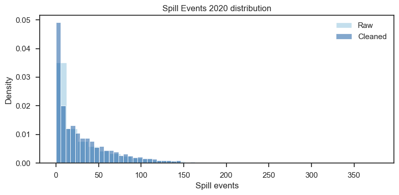

```python
target_spill_col = next((col for col in comparison_config.spill_year_columns if col in raw_sample_pdf.columns), None)
if target_spill_col:
    fig, ax = plt.subplots(figsize=(8, 4))
    sns.histplot(
        raw_sample_pdf[target_spill_col].dropna(),
        bins=30,
        color="#9ecae1",
        label="Raw",
        ax=ax,
        stat="density",
        alpha=0.6,
    )
    sns.histplot(
        clean_sample_pdf[target_spill_col].dropna(),
        bins=30,
        color="#08519c",
        label="Cleaned",
        ax=ax,
        stat="density",
        alpha=0.5,
    )
    ax.set_title(f"{target_spill_col} distribution")
    ax.set_xlabel("Spill events")
    ax.legend()
    plt.tight_layout()
    plt.show()
else:
    print("No spill event columns found in the sample.")
```

### Geographic footprint

Use side-by-side scatter plots to see how invalid coordinates were removed.

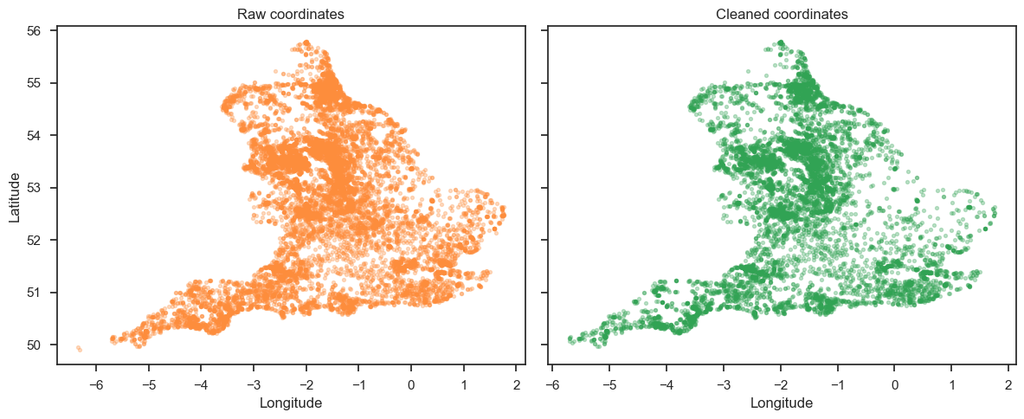

```python
coord_cols = [col for col in ["Latitude", "Longitude"] if col in raw_sample_pdf.columns]
if len(coord_cols) == 2:
    fig, axes = plt.subplots(1, 2, figsize=(12, 5), sharey=True)
    raw_coords = raw_sample_pdf.dropna(subset=coord_cols)
    clean_coords = clean_sample_pdf.dropna(subset=coord_cols)

    axes[0].scatter(
        raw_coords["Longitude"],
        raw_coords["Latitude"],
        s=8,
        alpha=0.3,
        color="#fd8d3c",
    )
    axes[0].set_title("Raw coordinates")
    axes[0].set_xlabel("Longitude")
    axes[0].set_ylabel("Latitude")

    axes[1].scatter(
        clean_coords["Longitude"],
        clean_coords["Latitude"],
        s=8,
        alpha=0.3,
        color="#31a354",
    )
    axes[1].set_title("Cleaned coordinates")
    axes[1].set_xlabel("Longitude")

    plt.tight_layout()
    plt.show()
else:
    print("Latitude/Longitude columns are not both available in the sample.")
```

### Water company coverage

Check whether the cleaning steps disproportionately impact specific companies.

```python
if "Water company" in raw_sample_pdf.columns:
    raw_counts = raw_sample_pdf["Water company"].value_counts().head(10)
    clean_counts = clean_sample_pdf["Water company"].value_counts().head(10)

    comparison = (
        pd.concat([raw_counts, clean_counts], axis=1, keys=["raw", "cleaned"])
        .fillna(0)
        .astype(int)
    )
    comparison
```

[output not shown]

### Removal breakdown & audit trail

Leverage the `CleaningReport` to explain exactly why rows were removed.

```python
pd.Series(cleaning_report.removal_breakdown).to_frame("rows_removed")
```

|  | rows_removed |
| --- | --- |
| insufficient_spill_years | 3253 |
| high_missing_values | 1990 |

```python
pd.DataFrame(
    {
        "errors": cleaning_report.errors or [],
        "warnings": cleaning_report.warnings or [],
    }
)
```

|  | errors | warnings |
| --- | --- | --- |

## Takeaways

- Pair these visuals with `export/cleaned_data` samples when presenting to stakeholders.
- Removal breakdown + company coverage highlights whether specific regions/companies need bespoke thresholds.
- Use this notebook as a regression harness whenever `WaterDataCleaner` logic changes.